# hw-03

Jerry Gu (S2785099)

2026-11-17

## Data load and preparation before modelling

```r
gss16<-read.csv("data/gss16.csv")
```

#### Cleaning and selecting columns

```r
gss16_advfront <- gss16 %>%
  select(advfront, emailhr, educ, polviews, wrkstat) %>%
  drop_na()
```

#### Re-levelling `advfront`

```r
gss16_advfront <- gss16_advfront %>%
  mutate(
    advfront = case_when(
      advfront == "Strongly agree" ~ "Agree",
      advfront == "Agree" ~ "Agree",
      TRUE ~ "Not agree"
    ),
    advfront = fct_relevel(advfront, "Not agree", "Agree")
  )
```

#### Re-levelling `polviews`

```r
gss16_advfront <- gss16_advfront %>%
  mutate(
    polviews = case_when(
      str_detect(polviews, "[Cc]onservative") ~ "Conservative",
      str_detect(polviews, "[Ll]iberal") ~ "Liberal",
      TRUE ~ polviews
    ),
    polviews = fct_relevel(polviews, "Conservative", "Moderate", "Liberal")
  )
```

## Exercise 1: Create a linear regression model

#### Exercise 1 (a)

```r
# Predict weekly email hours from years of education.
email_model <- linear_reg() %>%
  set_engine("lm") %>%
  fit(emailhr ~ educ, data = gss16_advfront)

tidy(email_model)
```

```
## # A tibble: 2 × 5
##   term        estimate std.error statistic       p.value
##   <chr>          <dbl>     <dbl>     <dbl>         <dbl>
## 1 (Intercept)   -2.76      1.66      -1.66 0.0970
## 2 educ           0.685     0.116      5.92 0.00000000413
```

Therefore the fitted line is:

$$\widehat{\text{emailhr}} = -2.757 +
0.685\,\text{educ}.$$

For each additional year of education, the model predicts about 0.685 more hours spent on email per week.

#### Exercise 1 (b)

```r
# Summarise the model fit.
glance(email_model)
```

```
## # A tibble: 1 × 12
##   r.squared adj.r.squared sigma statistic       p.value    df logLik   AIC   BIC
##       <dbl>         <dbl> <dbl>     <dbl>         <dbl> <dbl>  <dbl> <dbl> <dbl>
## 1    0.0291        0.0283  10.9      35.1 0.00000000413     1 -4458. 8922. 8937.
## # ℹ 3 more variables: deviance <dbl>, df.residual <int>, nobs <int>
```

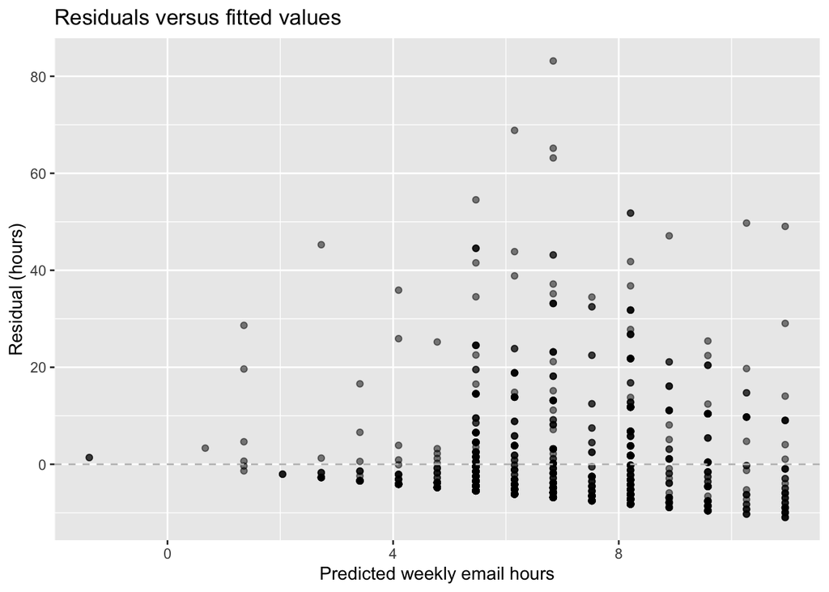

```r
# Plot residuals against fitted values.
email_residuals <- augment(email_model$fit)

ggplot(email_residuals, aes(x = .fitted, y = .resid)) +
  geom_point(alpha = 0.5) +
  geom_hline(yintercept = 0, color = "gray", lty = "dashed") +
  labs(
    title = "Residuals versus fitted values",
    x = "Predicted weekly email hours",
    y = "Residual (hours)"
  )
```

The model explains about 2.9% of the variation in weekly email hours, and the residual standard error is about 10.9 hours. The residual plot shows several large positive residuals, including one of about 83 hours. Overall, years of education alone does a poor job of predicting weekly email hours.

## Exercise 2: Compare two linear models

#### Exercise 2 (a)

```r
# Add research support as a predictor.
email_model_2 <- linear_reg() %>%
  set_engine("lm") %>%
  fit(emailhr ~ educ + advfront, data = gss16_advfront)

tidy(email_model_2)
```

```
## # A tibble: 3 × 5
##   term          estimate std.error statistic       p.value
##   <chr>            <dbl>     <dbl>     <dbl>         <dbl>
## 1 (Intercept)     -3.06      1.76     -1.74  0.0820
## 2 educ             0.678     0.117     5.80  0.00000000830
## 3 advfrontAgree    0.481     0.918     0.524 0.601
```

```r
# Compare the two model fits.
glance(email_model)
```

```
## # A tibble: 1 × 12
##   r.squared adj.r.squared sigma statistic       p.value    df logLik   AIC   BIC
##       <dbl>         <dbl> <dbl>     <dbl>         <dbl> <dbl>  <dbl> <dbl> <dbl>
## 1    0.0291        0.0283  10.9      35.1 0.00000000413     1 -4458. 8922. 8937.
## # ℹ 3 more variables: deviance <dbl>, df.residual <int>, nobs <int>
```

```r
glance(email_model_2)
```

```
## # A tibble: 1 × 12
##   r.squared adj.r.squared sigma statistic      p.value    df logLik   AIC   BIC
##       <dbl>         <dbl> <dbl>     <dbl>        <dbl> <dbl>  <dbl> <dbl> <dbl>
## 1    0.0293        0.0277  10.9      17.7 0.0000000275     2 -4458. 8923. 8944.
## # ℹ 3 more variables: deviance <dbl>, df.residual <int>, nobs <int>
```

Both models explain about 2.9% of the variation in weekly email hours. Adding `advfront` increases R^2 slightly, but adjusted R^2 falls from 0.02829 to 0.02769. Since adjusted R^2 accounts for the extra predictor, I would prefer the simpler model with education alone.

## Exercise 3: Create a workflow to fit a model

```r
set.seed(1234)
gss16_split <- initial_split(gss16_advfront)
gss16_train <- training(gss16_split)
gss16_test  <- testing(gss16_split)
```

#### Exercise 3 (a)

```r
# Set up the logistic regression workflow.
gss16_rec_1 <- recipe(advfront ~ educ, data = gss16_train)

gss16_mod_1 <- logistic_reg() %>%
  set_engine("glm")

gss16_wflow_1 <- workflow() %>%
  add_model(gss16_mod_1) %>%
  add_recipe(gss16_rec_1)

gss16_wflow_1
```

```
## ══ Workflow ════════════════════════════════════════════════════════════════════
## Preprocessor: Recipe
## Model: logistic_reg()
##
## ── Preprocessor ────────────────────────────────────────────────────────────────
## 0 Recipe Steps
##
## ── Model ───────────────────────────────────────────────────────────────────────
## Logistic Regression Model Specification (classification)
##
## Computational engine: glm
```

I chose logistic regression because `advfront` has two categories, Agree and Not agree. The model uses years of education to estimate the probability of an Agree response.

#### Exercise 3 (b)

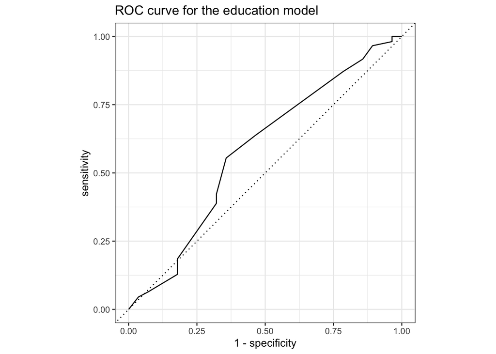

```r
# Fit the model on the training data.
gss16_fit_1 <- gss16_wflow_1 %>%
  fit(data = gss16_train)

# Predict probabilities on the test data.
gss16_pred_1 <- predict(gss16_fit_1, gss16_test, type = "prob") %>%
  bind_cols(gss16_test)

# Plot the ROC curve for Agree.
gss16_pred_1 %>%
  roc_curve(
    truth = advfront,
    .pred_Agree,
    event_level = "second"
  ) %>%
  autoplot() +
  labs(title = "ROC curve for the education model")
```

The ROC curve is mostly above the diagonal, but it stays fairly close to it. This suggests that years of education alone has limited ability to distinguish between Agree and Not agree responses in the test data.

## Exercise 4: Performance of a logistic regression

#### Exercise 4 (a)

```r
# Classify test responses and count the outcomes.
gss16_pred_1 %>%
  mutate(predicted = if_else(.pred_Agree >= 0.83, "Agree", "Not agree")) %>%
  summarise(
    TP = sum(predicted == "Agree" & advfront == "Agree"),
    TN = sum(predicted == "Not agree" & advfront == "Not agree"),
    FP = sum(predicted == "Agree" & advfront == "Not agree"),
    FN = sum(predicted == "Not agree" & advfront == "Agree")
  ) %>%
  mutate(
    sensitivity = TP / (TP + FN),
    specificity = TN / (TN + FP)
  )
```

```
## # A tibble: 1 × 6
##      TP    TN    FP    FN sensitivity specificity
##   <int> <int> <int> <int>       <dbl>       <dbl>
## 1   147    18    10   118       0.555       0.643
```

At the 0.83 cutoff, the model correctly identifies 147 of the 265 Agree responses, giving a sensitivity of 55.5%. It also correctly identifies 18 of the 28 Not agree responses, giving a specificity of 64.3%.

#### Exercise 4 (b)

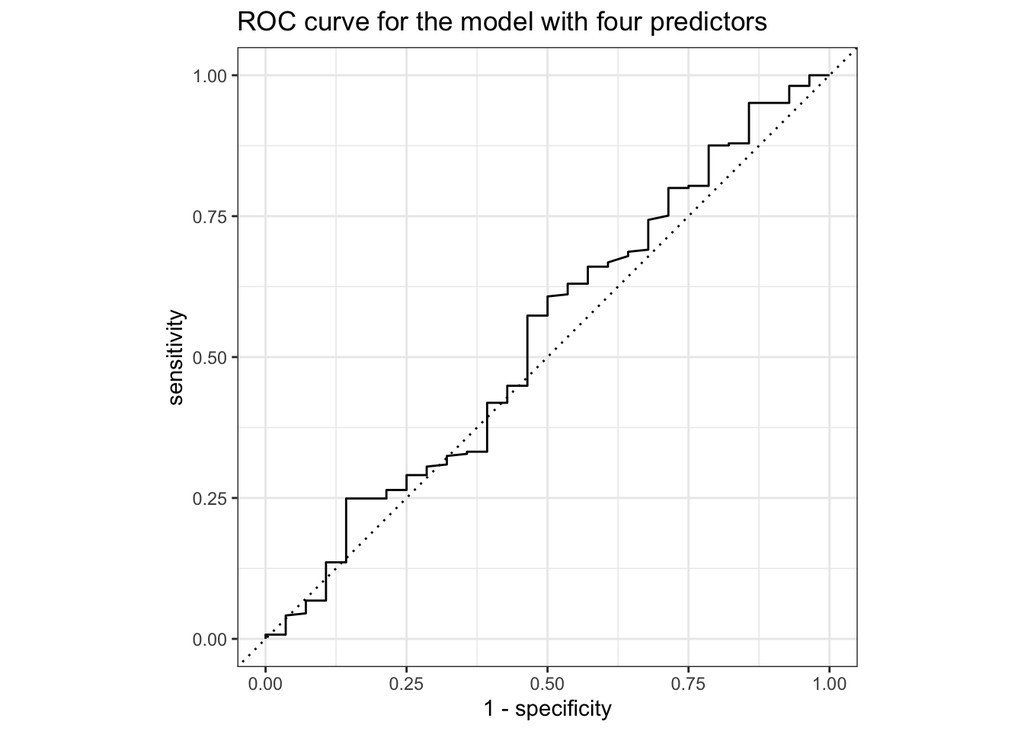

```r
# Set up the model with four predictors.
gss16_rec_2 <- recipe(
  advfront ~ polviews + wrkstat + emailhr + educ,
  data = gss16_train
) %>%
  step_dummy(all_nominal(), -all_outcomes())

gss16_mod_2 <- logistic_reg() %>%
  set_engine("glm")

gss16_wflow_2 <- workflow() %>%
  add_model(gss16_mod_2) %>%
  add_recipe(gss16_rec_2)

# Fit model 2 and predict on the test data.
gss16_fit_2 <- gss16_wflow_2 %>%
  fit(data = gss16_train)

gss16_pred_2 <- predict(gss16_fit_2, gss16_test, type = "prob") %>%
  bind_cols(gss16_test)

# Plot the ROC curve for model 2.
gss16_pred_2 %>%
  roc_curve(truth = advfront, .pred_Agree, event_level = "second") %>%
  autoplot() +
  labs(title = "ROC curve for the model with four predictors")
```

```r
# Compare test AUC for models 1 and 2.
gss16_pred_1 %>%
  roc_auc(truth = advfront, .pred_Agree, event_level = "second")
```

```
## # A tibble: 1 × 3
##   .metric .estimator .estimate
##   <chr>   <chr>          <dbl>
## 1 roc_auc binary         0.581
```

```r
gss16_pred_2 %>%
  roc_auc(truth = advfront, .pred_Agree, event_level = "second")
```

```
## # A tibble: 1 × 3
##   .metric .estimator .estimate
##   <chr>   <chr>          <dbl>
## 1 roc_auc binary         0.535
```

On the same test set, the model using only years of education had an AUC of 0.581, compared with 0.535 for the model with four predictors. The education model performed slightly better, but both AUC values are close to 0.5. This suggests that both models have limited ability to distinguish between Agree and Not agree responses.